# Homework 1

Julio Cesar Enciso-Alva

**Note:** This documents uses the package `magrittr`.

## Question 1

### a)

The multiplication will be calculated using the matrix product operator `%*%`. In order to do that, the given matrices are saved to the variables `A` and `B`.

```r
A = matrix(c(7,9,20, 2,4,10),ncol=3)
B = matrix(c(1,7,12,40, 2,8,13,20, 3,9,14,21),ncol=4)
```

Then, the multiplication is calculated and displayed.

```r
A.B = A %*% B
A.B
```

```
##      [,1] [,2] [,3] [,4]
## [1,]  195  352  503  427
## [2,]  143  444  187  319
```

### b)

The matrix $G$ will be constructed using the spectral decomposition of $A$; if we have an ortonormal matrix $C$ and a diagonal matrix $D$ such that

$$A = C D C'$$

then its *square root* can be constructed (and will be proposed as the solution) using the following expression
$$G = C D^\frac{1}{2} C'$$

As the first step for doing so, the matrix $A$ is saved to the variable `A`.

```r
A = matrix(c(2,1,0, 1,2,0, 0,0,2),ncol=3)
A
```

```
##      [,1] [,2] [,3]
## [1,]    2    1    0
## [2,]    1    2    0
## [3,]    0    0    2
```

The spectral decomposition of $A$ is found using the function `base::eigen`. It is important to recall that the matrices $C$ and $D$ such that $A = C D C'$ can be constructed as

$$\begin{align*}
C &= [x_1,x_2,x_3] \\
D &= \textrm{diag}(\lambda_1,\lambda_2,\lambda_3)
\end{align*}$$

where $x_i$ are the eigenvectors of $A$, and $\lambda_i$ are their corresponding eigenvalues. Both values are saved to the variable `SD`.

```r
SD = eigen(A)
C = SD$vectors
D = diag(SD$values)
```

The matrix G, the **proposed solution**, is constructed as described before:

```r
G = C %*% sqrt(D) %*% t(C)
G
```

```
##           [,1]      [,2]     [,3]
## [1,] 1.3660254 0.3660254 0.000000
## [2,] 0.3660254 1.3660254 0.000000
## [3,] 0.0000000 0.0000000 1.414214
```

In order to verify that $G^2=A$, both $G^2$ and $A$ are displayed

```r
A
```

```
##      [,1] [,2] [,3]
## [1,]    2    1    0
## [2,]    1    2    0
## [3,]    0    0    2
```

```r
G %*% G
```

```
##      [,1] [,2] [,3]
## [1,]    2    1    0
## [2,]    1    2    0
## [3,]    0    0    2
```

**Note:** The function `identical` fails due to numerical truncation.

```r
identical(A,G %*% G)
```

```
## [1] FALSE
```

```r
A-G %*% G
```

```
##               [,1]          [,2]          [,3]
## [1,] -4.440892e-16 -2.220446e-16  0.000000e+00
## [2,]  3.330669e-16 -4.440892e-16  0.000000e+00
## [3,]  0.000000e+00  0.000000e+00 -4.440892e-16
```

### c)

The expression requested is
$$\Phi(x) = \int_{-\infty}^x \frac{1}{\sqrt{2\pi}} e^{-\frac{z^2}{2}}\, dz$$

## Question 2

To perform the clusterings, the given distance matrix was saved on the file `DistMat.csv`; the data is then loaded and saved to the variable `d`. For ease of use, only the lower half of the matrix is in the file.

```r
d = read.csv('./DistMat.csv',header=F) %>%
  as.matrix() %>% as.dist()
```

The dendrograms are generated using the function `stats::hclust`, changing the method of clustering.

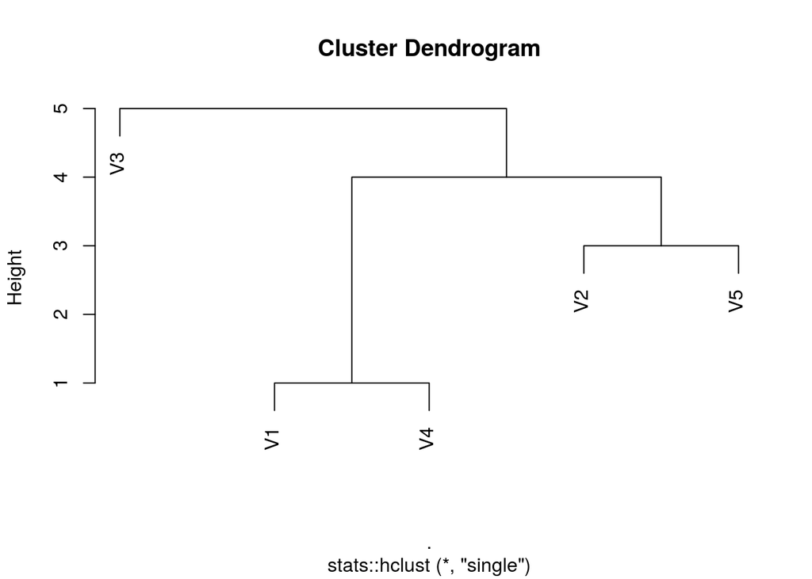

```r
d %>% stats::hclust(method='single') %>% plot()
```

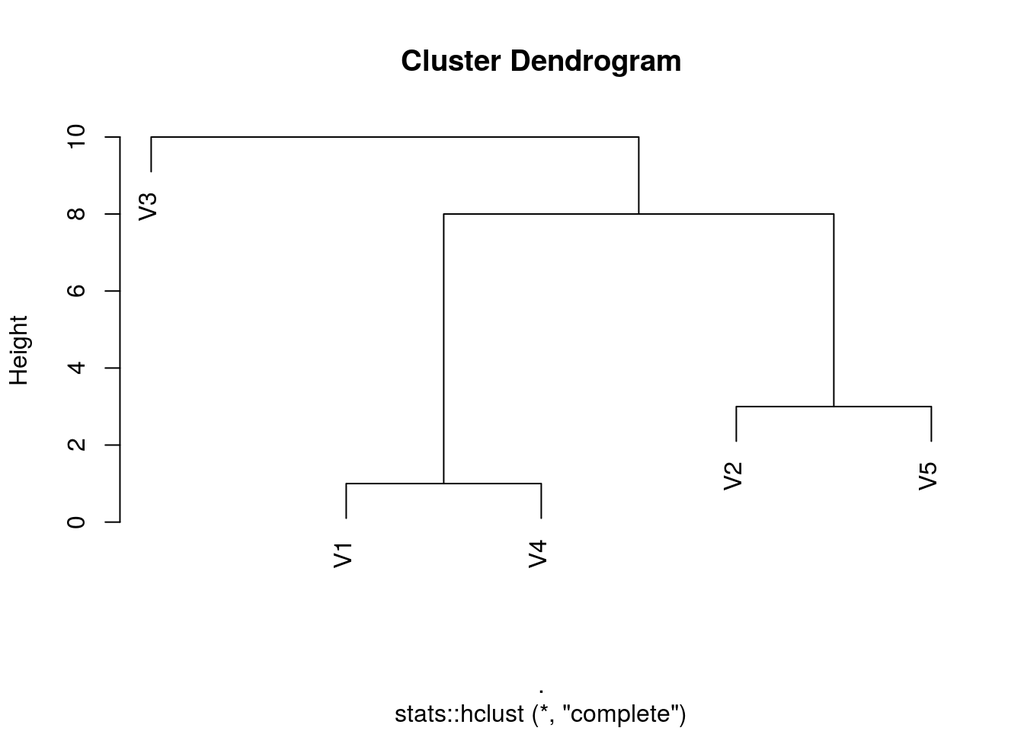

```r
d %>% stats::hclust(method='complete') %>% plot()
```

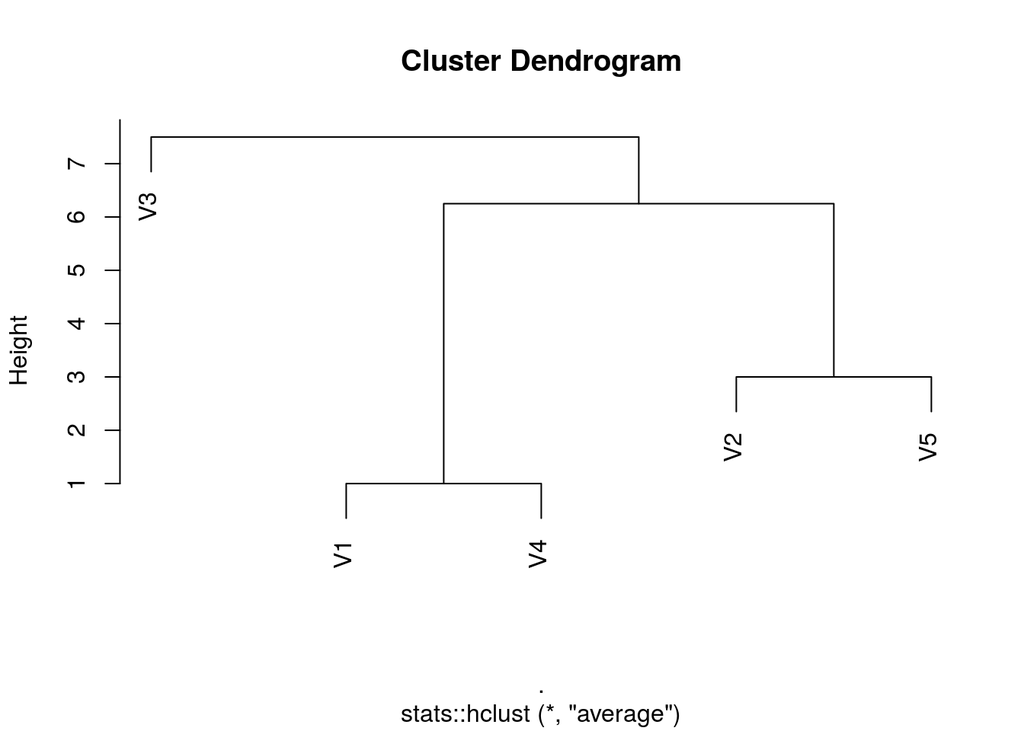

```r
d %>% stats::hclust(method='average') %>% plot()
```

The three dendrograms have the same structure, but the nodes have different heights. This indicates that the clusters are robust.

## Question 3

The dataset `cereal` is loaded from a local copy using the suggested code; the column names are also read from a file. The variables `Manufacturer` and `Group are dropped`.

```r
require('data.table')
cereal = fread("./T11-9.txt", data.table = F)
colnames(cereal) = scan(what="character", n=11, file='ColumnNames.txt')

rownames(cereal) = cereal[,1]
cereal = cereal[,-1]

cereal = colnames(cereal) %>% setdiff(c('Manufacturer','Group')) %>% cereal[.]
```

### a)

The distance between vectors is calculated using the function `stats::dist` and saved to the variable `d`.

```r
d = stats::dist(cereal, method='euclidean')
```

### b)

The clustering is achieved using the funcion `stats::hclust`, using different methods.

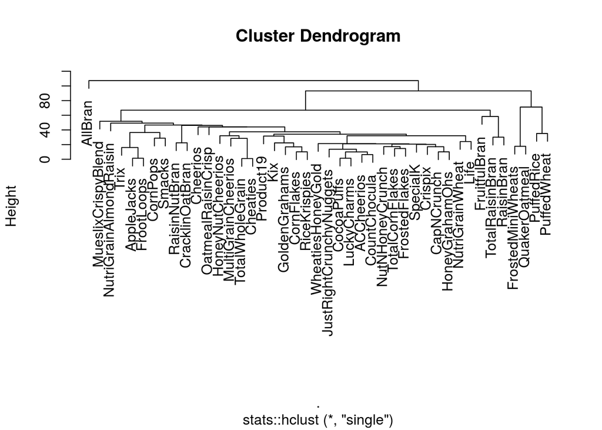

```r
d %>% stats::hclust(method='single') %>% plot()
```

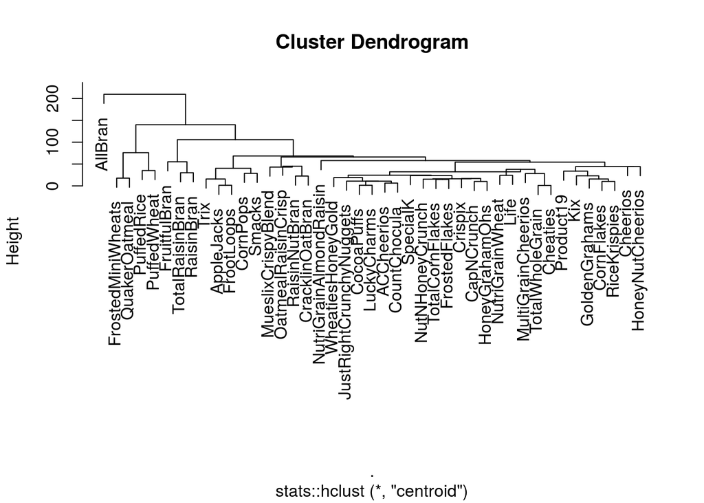

```r
d %>% stats::hclust(method='centroid') %>% plot()
```

The clusters differ with the two methods. There are inversions on the *centroid* clustering, possible related to healthy low-sugar cereals. This difference can be explained by the effect of the variables `Calories`, `Sodium` and `Potassium`; those variables have very high values because of the scale.

## Question 4

```r
require('data.table')
cereal = fread("./T11-9.txt", data.table = F)
colnames(cereal) = scan(what="character", n=11, file='ColumnNames.txt')

rownames(cereal) = cereal[,1]
cereal = cereal[,-1]

cereal = colnames(cereal) %>% setdiff(c('Manufacturer','Group')) %>% cereal[.]
```

## Question 5

The required vector is generated and saved to the variable `x`, and then the required tasks are completed.

```r
set.seed(1)
x = rnorm(10000)
```

### a)

```r
length( x[ -2<x & x<2 ] )
```

```
## [1] 9498
```

There are 9498 values in `x` between -2 and 2.

### b)

The indexes of `x`, whose values lie are on the set $(-\infty,-3]\cup[3,\infty)$, are saved to the variable `IND` and displayed.

```r
IND = c( which(x<=-3 | x>=3) )
IND
```

```
##  [1]  446  495  843 1165 1295 1442 1737 2132 2460 3331 3680 3694 3751 4262
## [15] 5641 5811 5904 6108 6270 6376 7485 7873 8203 8216 8711 8757 9612 9777
```

### c)

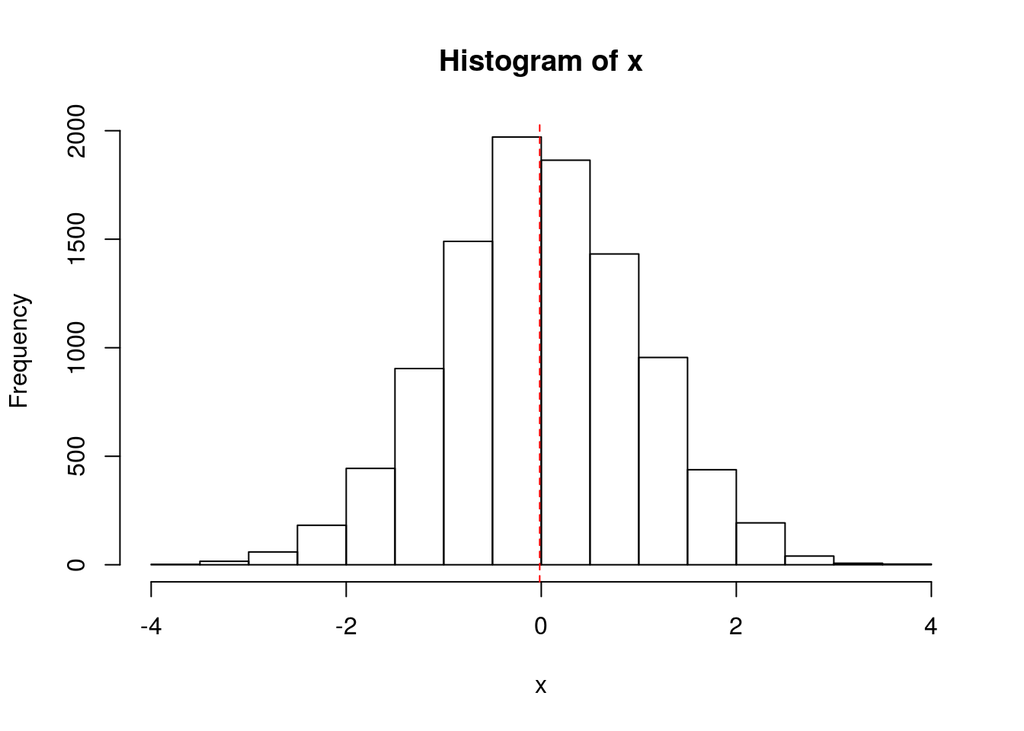

```r
hist(x)
abline(v=median(x),lty=2,col='red')
```

## Question 6

The dataset `cereal` is loaded from a local copy using the suggested code; the column names are also read from a file. The variable `Group` is dropped.

**Note:** This process was done in *Question 3* and *Question 4*, but is done again to keep the code independent, and also because variable `Manufacturer` is not dropped in this question.

```r
require('data.table')
cereal = fread("./T11-9.txt", data.table = F)
colnames(cereal) = scan(what="character", n=11, file='ColumnNames.txt')

rownames(cereal) = cereal[,1]
cereal = cereal[,-1]

cereal = colnames(cereal) %>% setdiff(c('Group')) %>% cereal[.]
```

### a)

```r
cereal %>%
  dplyr::filter( Protein>=3 & Sugar<=9 ) %>%
  dplyr::group_by(Manufacturer) %>%
  dplyr::summarize(Mean_Calories=mean(Calories)) %>%
  knitr::kable()
```

| Manufacturer | Mean_Calories |
| --- | --- |
| G | 102.5000 |
| K | 102.8571 |
| Q | 100.0000 |

### b)

```r
cereal$Healthy = 1*(cereal$Protein>=3 & cereal$Sugar<=9)
```